# Practical 1 — Airline Passengers

# Practical 1A

### Introduction to Time Series Analysis with R

## 1. Importing data files with RStudio & preliminary manipulations.

As first thing in this practical, we will import a time series data set from RStudio itself, and we will see how to create the same time series manually step-by-step, by using the “ts” function from the “tseries” package.

```r
#1. Importing data files with RStudio & preliminary manipulations.
# Import AirPassengers file from RStudio data

library(readxl)
library(tseries)

data("AirPassengers")
AP<- AirPassengers
print("Time series from the AirPassenger dataset (TIME SERIES AP):")
```

```
## [1] "Time series from the AirPassenger dataset (TIME SERIES AP):"
```

```r
AP
```

```
##      Jan Feb Mar Apr May Jun Jul Aug Sep Oct Nov Dec
## 1949 112 118 132 129 121 135 148 148 136 119 104 118
## 1950 115 126 141 135 125 149 170 170 158 133 114 140
## 1951 145 150 178 163 172 178 199 199 184 162 146 166
## 1952 171 180 193 181 183 218 230 242 209 191 172 194
## 1953 196 196 236 235 229 243 264 272 237 211 180 201
## 1954 204 188 235 227 234 264 302 293 259 229 203 229
## 1955 242 233 267 269 270 315 364 347 312 274 237 278
## 1956 284 277 317 313 318 374 413 405 355 306 271 306
## 1957 315 301 356 348 355 422 465 467 404 347 305 336
## 1958 340 318 362 348 363 435 491 505 404 359 310 337
## 1959 360 342 406 396 420 472 548 559 463 407 362 405
## 1960 417 391 419 461 472 535 622 606 508 461 390 432
```

```r
cat("\n")
```

```r
cat("Class type of the latter time series:", class(AP), "\n")
```

```
## Class type of the latter time series: ts
```

```r
# Save number of passengers in vector x and date (time) in vector t
x <- as.numeric(AP)
t <- time(AP)

cat("\n")
```

```r
# Create a time series using the "tseries" package, with periodicity 12 months (frequency=12) and starting from 1949,
# We will use the same numbers of passengers as given in the AirPassenger data (i.e. "x")
xt<-ts(x,start=1949,frequency=12)
print("Time series created manually, using passengers numbers from AirPassenger dataset (TIME SERIES xt):")
```

```
## [1] "Time series created manually, using passengers numbers from AirPassenger dataset (TIME SERIES xt):"
```

```r
xt
```

```
##      Jan Feb Mar Apr May Jun Jul Aug Sep Oct Nov Dec
## 1949 112 118 132 129 121 135 148 148 136 119 104 118
## 1950 115 126 141 135 125 149 170 170 158 133 114 140
## 1951 145 150 178 163 172 178 199 199 184 162 146 166
## 1952 171 180 193 181 183 218 230 242 209 191 172 194
## 1953 196 196 236 235 229 243 264 272 237 211 180 201
## 1954 204 188 235 227 234 264 302 293 259 229 203 229
## 1955 242 233 267 269 270 315 364 347 312 274 237 278
## 1956 284 277 317 313 318 374 413 405 355 306 271 306
## 1957 315 301 356 348 355 422 465 467 404 347 305 336
## 1958 340 318 362 348 363 435 491 505 404 359 310 337
## 1959 360 342 406 396 420 472 548 559 463 407 362 405
## 1960 417 391 419 461 472 535 622 606 508 461 390 432
```

```r
cat("\n")
```

```r
cat("Class type of the latter time series:", class(xt), "\n")
```

```
## Class type of the latter time series: ts
```

```r
# xt and AP are two identical time series, just created in two different ways.
```

As expected, both time series “AP” and “xt” are the same, both in terms of time, frequency, passengers and class types (they both are class type ts). Let’s now explore the summary statistics of the time series “AP”:

```r
summary(AP)
```

```
##    Min. 1st Qu.  Median    Mean 3rd Qu.    Max.
##   104.0   180.0   265.5   280.3   360.5   622.0
```

These numbers are coherent with the plot below, titled “Airline Passengers”, where indeed minimum values are around 100 passengers (104) and maximum are around 600 passengers (622).

## 2. Graphical representation

We will see different options to plot the time series:

- we will try the two cases suggested by the practical (represent datapoints with circles and connect them with lines, or represent datapoints with a number representing the n. of passengers)
- and we will experiment few more options discovered through the “help” function of “plot”, such as: histogram, only points, stair steps (discretized view)

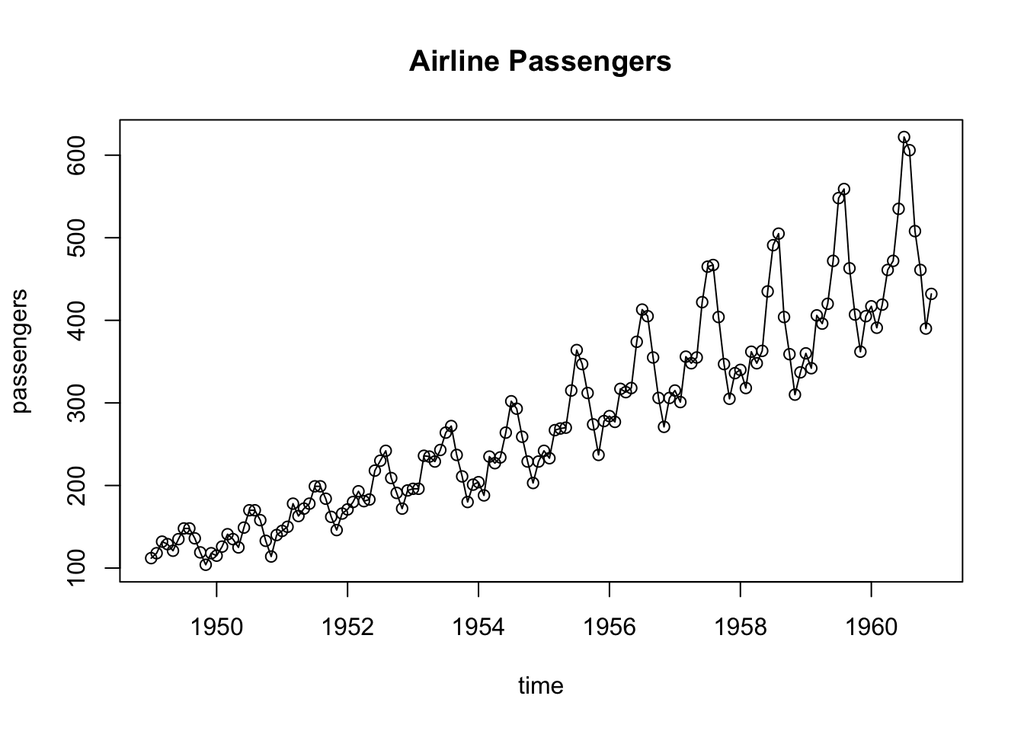

```r
# Option 1 for plotting: lines connected through circles
# In this case first argument is time series as one unique element (xt)
plot(xt, main="Airline Passengers", xlab="time", ylab="passengers", type="o")
```

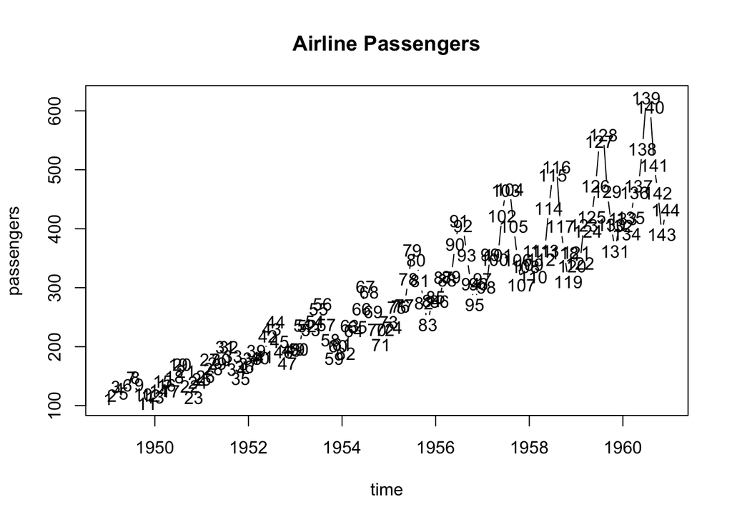

```r
# Option 2 for plotting: lines connected through numbers
# In this case the time series is composed by the vectors x and t, so both have to be given as first arguments:
# time on x-axis (so t is the 1° argument) and number of passengers on y-axis (so x is the 2° argument)
plot(t, x, main="Airline Passengers", xlab="time", ylab="passengers", type="l")
```

```r
# Check the help for the “plot” function, in particular the different options for “type”.
help("plot")
```

```
## Help on topic 'plot' was found in the following packages:
##
##   Package               Library
##   base                  /Library/Frameworks/R.framework/Resources/library
##   graphics              /Library/Frameworks/R.framework/Versions/4.4-arm64/Resources/library
##
##
## Using the first match ...
```

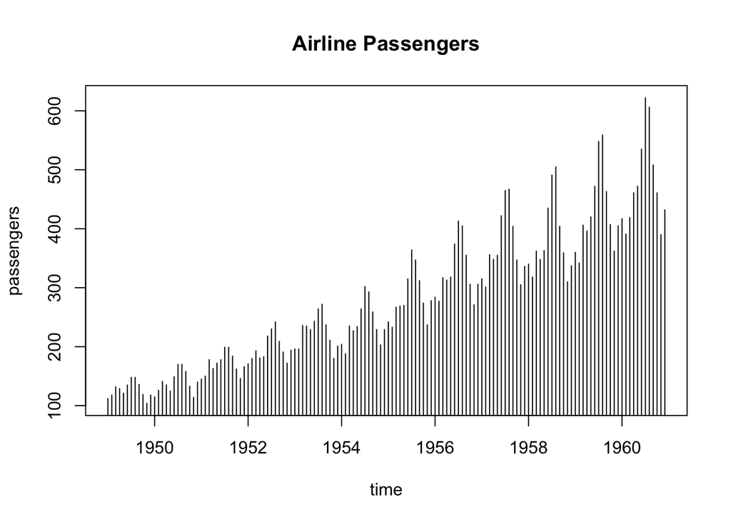

```r
# I will try to plot the histogram
plot(xt, main="Airline Passengers", xlab="time", ylab="passengers", type="h")
```

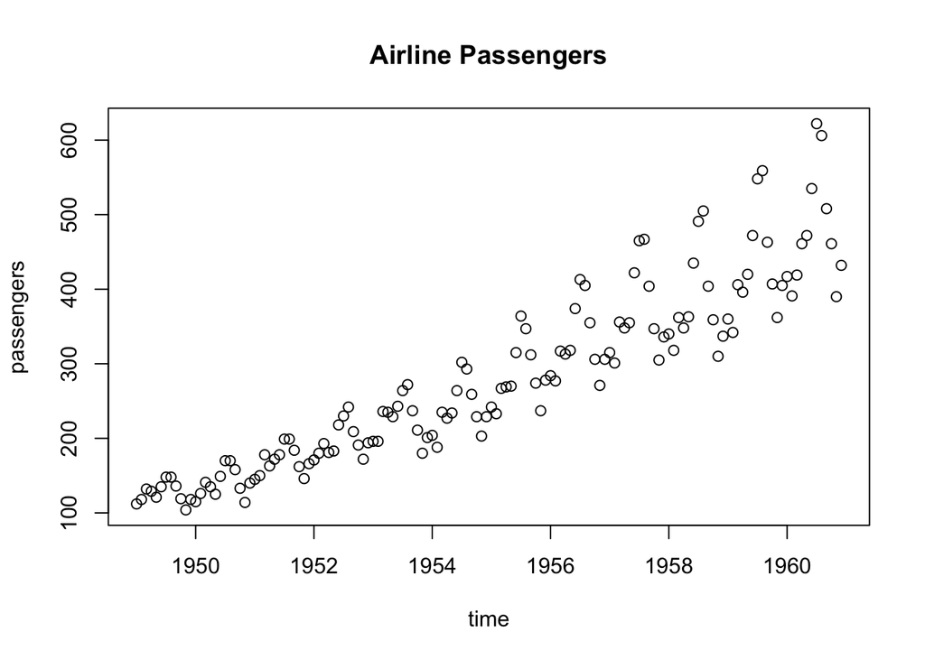

```r
# Plot only the points
plot(xt, main="Airline Passengers", xlab="time", ylab="passengers", type="p")
```

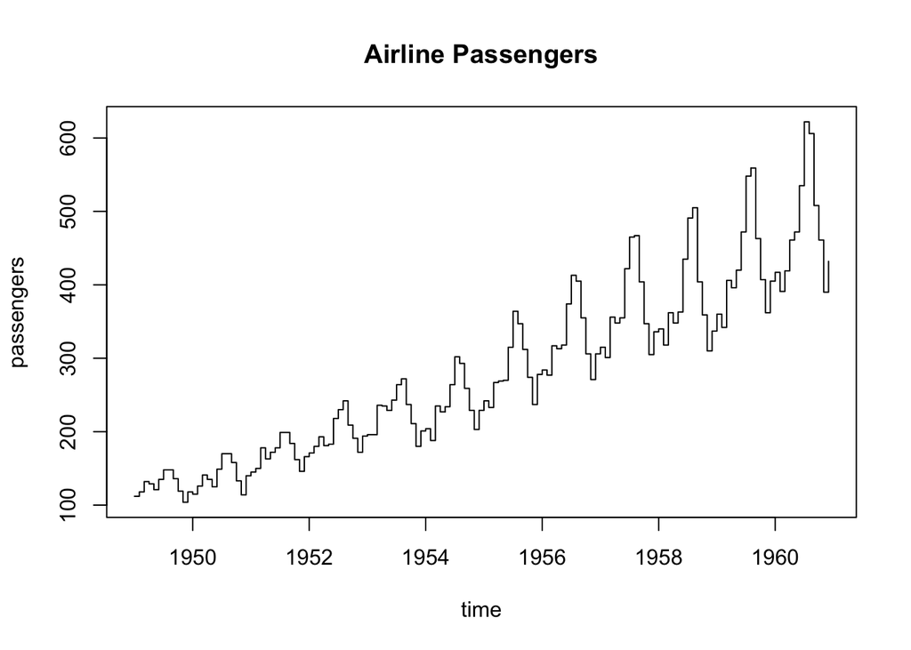

```r
# Plot stair steps
plot(xt, main="Airline Passengers", xlab="time", ylab="passengers", type="s")
```

In this case, we can observe that the series shows an overall increasing trend over the years. However, it may not always be trivial to see the global trend - as time series data are often characterized by fluctuations, short-term increases and decreases, and irregular spikes.

For this purpose, we use the aggregate function: it summarizes (with a sum function) the amount of passengers per year. This results in a much smoother plot, allowing us to visualize the underlying trend more clearly.

Furthermore, it is useful to understand how values typically vary across months within a year. For this, we use the cycle function: it groups the number of passengers by month, so that we can easily visualize the average number of passengers per month and their range of observed values. This will be shown in the boxplot below.

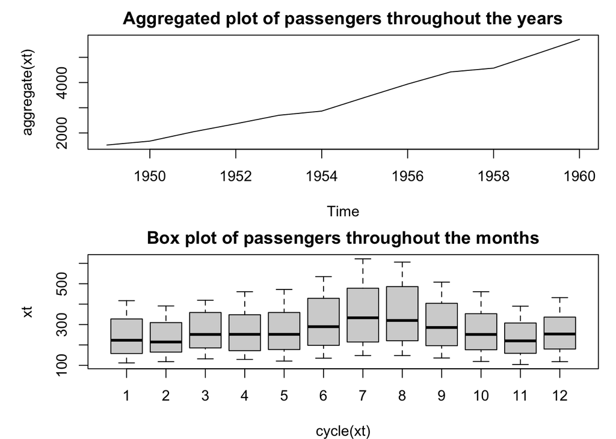

```r
# Another interesting option is to use "aggregate" and "cycle" to make a yearly summary:
layout(1:2, heights = c(4, 4))  # we add "heights" parameter so that the scale of y-axis is bigger and we are able to see more values on the y-axis (otherwise we could only see the minimum values)
par(mar = c(4, 5, 2, 1))  # more room for y-axis labels
plot(aggregate(xt), main="Aggregated plot of passengers throughout the years") #aggregate collapses the series by applying a summarizing function (by default sum) over each cycle
                    #for example with monthly & yearly data like in AirPassengers dataset, it groups all months of each year together so that we can visualize the total number of passengers for each year

boxplot(xt~cycle(xt), main="Box plot of passengers throughout the months") #Create box plots of the time series grouped by its seasonal cycle (12 monhts)
```